# Simulations continued

```r
library(tidyverse)
library(ggdist)
library(broom)
library(performance)
```

# Comparing multiple conditions

In many cases, we’ll want to compare results from a model under a wide range of different conditions so we can explore things like the relationship between sample size and Type II error rates. We can use a nested loop to run simulations across a range of different parameter values.

For instance, here’s how we would run the same simulation at a sample size of 50, 500, and 5000:

```r
set.seed(999)
sample_size<-c(50, 500, 5000)
result_frame<-tibble()
for(N in sample_size){
  iterations<-1000
  beta_0 <- 1
  beta_1 <- 0.05
  coefs<-list()
  # The simulation
  for (i in 1:iterations) {
    X <- rnorm(N, mean = 0, sd = 1) # an independent variable
    e <- rnorm(N, mean = 0, sd = 1) # the error term
    Y <- beta_0 + X * beta_1 + e # the dependent variable
    mod <- lm(Y ~ X)
    coefs[[i]] <- tidy(mod, conf.int = TRUE, conf.level = .95)
  }

  # combine results
  coefmat<-bind_rows(coefs, .id='iteration')
  # add a variable to indicate the condition applied for this loop
  coefmat$sample_size <- N
  # add the rows to a data frame
  result_frame<-bind_rows(result_frame, coefmat)

}

# how often do we have a type II error at N=50, 500, or 5000?
result_frame|>
  filter(term == "X")|>
  group_by(sample_size)|>
  summarise(`proportion p>=.05` = mean(p.value>=.05))
```

| sample_size | proportion p>=.05 |
| --- | --- |
| 50 | 0.922 |
| 500 | 0.783 |
| 5000 | 0.058 |

What if we wanted to look at our Type II error rates when N=50 while varying the effect size for $\beta_1$?

To do this, we just need to change a few lines of our loop:

```r
set.seed(999)
N <- 50                  # set a fixed value for N
betas <- c(0.05, 0.1, 1) # Make a vector of betas

result_frame<-tibble()
for(b in betas){
  iterations<-1000
  beta_0 <- 1
  beta_1 <- b
  coefs<-list()
  for (i in 1:iterations) {
    X <- rnorm(N, mean = 0, sd = 1)
    e <- rnorm(N, mean = 0, sd = 1)
    Y <- beta_0 + X * beta_1 + e
    mod <- lm(Y ~ X)
    coefs[[i]] <- tidy(mod, conf.int = TRUE, conf.level = .95)
  }

  coefmat<-bind_rows(coefs, .id='iteration')

  coefmat$beta_1 <- b # add a column to indicate the beta value in this simulation

  result_frame<-bind_rows(result_frame, coefmat)

}
```

And now we can estimate the type II error rate across these simulations:

```r
# how often do we have a type II error at b = 0.05, 0.10, or 1 and N = 50?
result_frame|>
  filter(term == "X")|>
  group_by(beta_1)|>
  summarise(`proportion p>=.05` = mean(p.value>=.05))
```

| beta_1 | proportion p>=.05 |
| --- | --- |
| 0.05 | 0.922 |
| 0.10 | 0.891 |
| 1.00 | 0.000 |

## Using a simulation function

writing multiple nested loops can get a little unwieldy, so we can simplify some of the code here by creating functions to handle the repetitive parts of this process.

The `runSim` function will take a data generating function `func` as an argument along with a data frame containing the arguments to use in each run of the simulation. The `aggregateResults` function will give us some summary statistics for the coefficient estimates across each run:

```r
# Runs the simulation across different parameter values  (replaces the outer loop in the prior examples)
runSim<-function(func, parmlist, iterations=1000, seed=NULL){
  if(!is.null(seed)){
    set.seed(seed)
  }
  all_results<-tibble()
  for(i in 1:length(parmlist)){
    result<-replicate(iterations, do.call(func, parmlist[[i]]), simplify=FALSE)|>
      bind_rows()
    result$condition<-i
    all_results<-bind_rows(all_results, result)

  }
  if(!is.null(names(parmlist))){
    all_results$condition <- factor(all_results$condition, labels=names(parmlist))
  }

  return(all_results)
}

# Function to get aggregate stats from model results
aggregateResults<-function(results){
  agged <- results |>
    group_by(condition, term) |>
    summarise(
      mean = mean(estimate),
      median = median(estimate),
      sd = sd(estimate),
      `2.5th percentile` = quantile(estimate, .025),
      `97.5th percentile` = quantile(estimate, .975),
      `proportion p>=.05` = mean(p.value >= .05),
      `proportion p<.05` = mean(p.value < .05)
    )
  return(agged)
}

# function to plot coefficients
plotCoefs<-function(results, term){
  results |>
    filter(term == term)|>
  ggplot(aes(x =estimate, y = condition)) +
  stat_halfeye(
    alpha = .5,
    width = .6,
    .width = 0,
    justification = -.2
  ) +
  geom_boxplot(width = .15, outlier.shape = NA) +
  theme_bw()
}
```

### Increasing N

Here’s an example of doing the same simulation we ran above using the `runSim` function. Instead of generating a nested loop, we just set up a list-of-lists containing the arguments that we want to pass to `genFunc`.

```r
# a data generation function with defaults (replaces the inner loop in the prior examples)
genFunc <- function(N, betas){
  X = cbind(rnorm(N, 0, 1))
  intercept = 1
  e = rnorm(N, 0 , 1)
  Y <- intercept  + X %*% betas + e
  mod <- lm(Y ~ X)
  coefs<-tidy(mod, conf.int = TRUE, conf.level = .95)
  return(coefs)

}


plist<-list(
  'N=50,   beta_1=0.05' =  list(betas=0.05, N=50),
  'N=100,  beta_1=0.05'=   list(betas=0.05, N=100),
  'N=1000, beta_1=0.05' =  list(betas=0.05, N=1000),
  "N=5000 beta_1 = 0.05 " =  list(betas=0.05, N=5000)
)
```

Then we pass `genFunc` and `plist` as arguments to `runSim`

```r
results<- runSim(func=genFunc,
                 parmlist = plist,
                 seed = 999
)
```

Now, we can summarize the results for each condition:

```r
# summarize the results
aggregateResults(results)|>
  filter(term=="X")
```

| condition | term | mean | median | sd | 2.5th percentile | 97.5th percentile | proportion p>=.05 | proportion p<.05 |
| --- | --- | --- | --- | --- | --- | --- | --- | --- |
| N=50, beta_1=0.05 | X | 0.05754167 | 0.05485753 | 0.14661228 | -0.23437526 | 0.34728955 | 0.922 | 0.078 |
| N=100, beta_1=0.05 | X | 0.04490034 | 0.04490392 | 0.10264734 | -0.16453195 | 0.23556999 | 0.925 | 0.075 |
| N=1000, beta_1=0.05 | X | 0.04876857 | 0.04912001 | 0.03245521 | -0.01280081 | 0.11011037 | 0.650 | 0.350 |
| N=5000 beta_1 = 0.05 | X | 0.04940107 | 0.04967229 | 0.01370838 | 0.02135950 | 0.07732701 | 0.059 | 0.941 |

What if we try different values for `beta_1` while using a sample size of 50?

```r
plist<-list(
  'N=50, beta_1=0.05' = list(betas= .05, N=50),
  'N=50, beta_1=0.1' =  list(betas= 0.1, N=50),
  'N=50, beta_1=1' =  list(betas= 1, N=50)
)

results<- runSim(func=genFunc,
           parmlist = plist,
           seed = 999
)

# summarize the results
aggregateResults(results)|>
  filter(term=="X")
```

| condition | term | mean | median | sd | 2.5th percentile | 97.5th percentile | proportion p>=.05 | proportion p<.05 |
| --- | --- | --- | --- | --- | --- | --- | --- | --- |
| N=50, beta_1=0.05 | X | 0.05754167 | 0.05485753 | 0.1466123 | -0.2343753 | 0.3472896 | 0.922 | 0.078 |
| N=50, beta_1=0.1 | X | 0.10143920 | 0.09350106 | 0.1444887 | -0.1881363 | 0.3926948 | 0.891 | 0.109 |
| N=50, beta_1=1 | X | 1.00518117 | 1.00993189 | 0.1411302 | 0.7255388 | 1.2910497 | 0.000 | 1.000 |

### More variance in the error term

What happens to the estimates if you increase the variance in the error term `e`? Start by modifying `genFunc` to allow us to set the standard deviation of the error term as a function argument (note, we can also include optional arguments to change the sample size and beta coefficients here, but we set them at some reasonable defaults)

```r
genFunc <- function(e_sd, N=1000, betas=1){
  X = cbind(rnorm(N, 0, 1))
  intercept = 1
  e = rnorm(N, 0 , sd=e_sd) # the variance of the error term
  Y <- intercept  + X %*% betas + e
  mod <- lm(Y ~ X)
  coefs<-tidy(mod, conf.int = TRUE, conf.level = .95)
  return(coefs)

}
```

Then create a nested list containing the set of parameter values you want to pass along to `genFunc` and pass them to the `runSim` argument.

```r
plist<-list(
  'sd(e) = 1' =   list(e_sd=1),
  'sd(e) = 10' =  list(e_sd=10),
  'sd(e) = 20' =  list(e_sd=20)
)


results<- runSim(func=genFunc,
           parmlist = plist,
           seed = 999
)

# summarize the results
aggregateResults(results)|>
  # we're really only interested in b_1 here, so we'll filter out the intercept:
  filter(term=="X")
```

| condition | term | mean | median | sd | 2.5th percentile | 97.5th percentile | proportion p>=.05 | proportion p<.05 |
| --- | --- | --- | --- | --- | --- | --- | --- | --- |
| sd(e) = 1 | X | 0.9989941 | 0.9995549 | 0.03186807 | 0.9387356 | 1.059337 | 0.000 | 1.000 |
| sd(e) = 10 | X | 0.9880112 | 0.9866158 | 0.32117683 | 0.3722518 | 1.596747 | 0.136 | 0.864 |
| sd(e) = 20 | X | 0.9969554 | 0.9963297 | 0.60998056 | -0.1605596 | 2.279022 | 0.667 | 0.333 |

Now plot the results

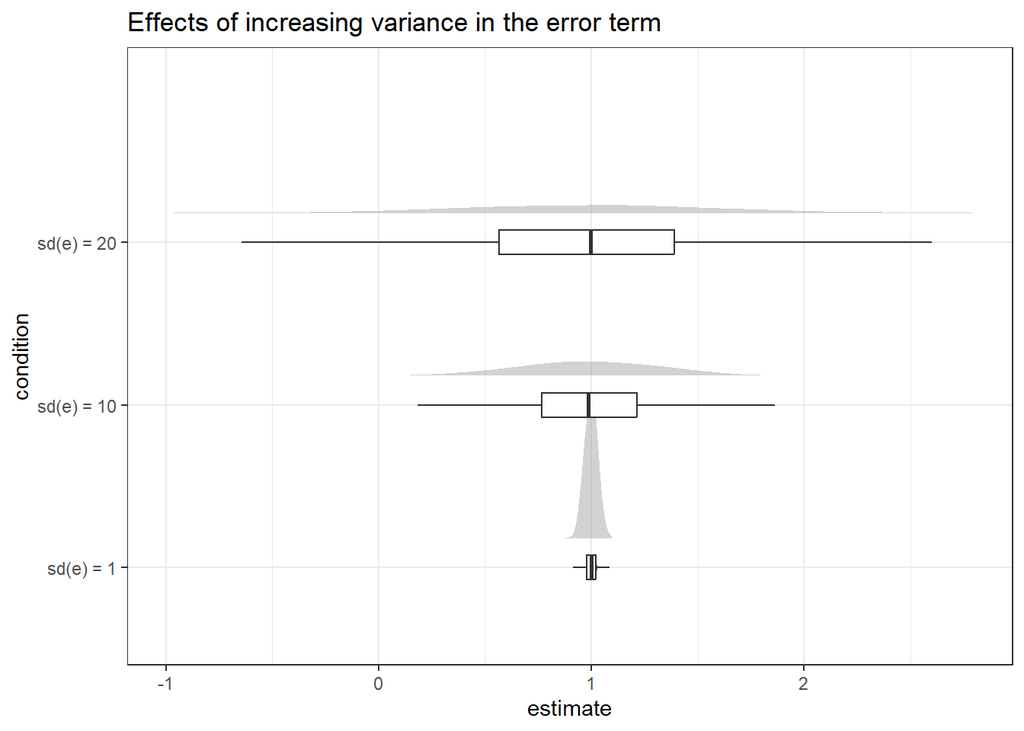

```r
results |>
  filter(term == "X")|>
  ggplot(aes(x = estimate, y = condition)) +
  stat_halfeye(
    alpha = .5,
    width = .6,
    .width = 0,
    justification = -.2
  ) +
  geom_boxplot(width = .15, outlier.shape = NA) +
  theme_bw() +
  ggtitle("Effects of increasing variance in the error term")
```

### Multicollinearity

We can use the same general approach to explore the effects of multicollinearity.

```r
genFunc <- function(corr_x=0, e_sd=1, N=1000, betas=c(1,1)){
  intercept = 1
  Sigma = matrix(c(1, corr_x, corr_x, 1), ncol=2)
  X = MASS::mvrnorm(N, mu=c(0, 0), Sigma=Sigma)
  e = rnorm(N, 0 , sd=e_sd) # the variance of the error term
  Y <- intercept  + X %*% betas + e
  mod <- lm(Y ~ X) # Omitting X[,2] from the regression model
  coefs<-tidy(mod, conf.int = TRUE, conf.level = .95)
  return(coefs)

}
```

Now we can see how our model performs with differing levels of multicollinearity.

```r
plist<-list(
  'r=-.7' =list(corr_x =  0.7),
  'r=  8' =list(corr_x =  0.8),
  'r= .9' =list(corr_x =  0.9)
)


results<-runSim( func=genFunc,
                 parmlist = plist,
                 seed = 999
                 )
```

How much do our estimates differ from the correct answer?

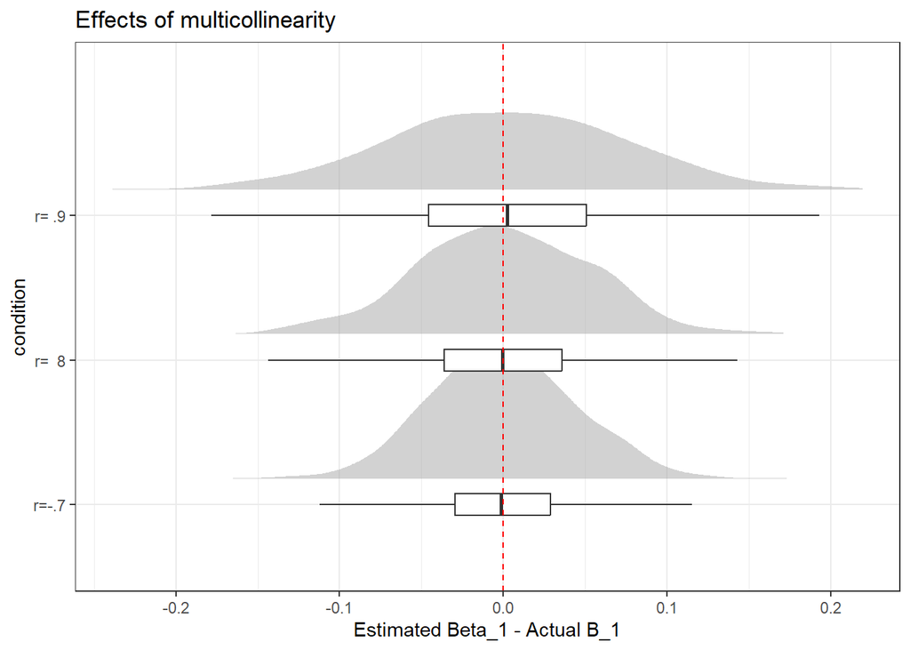

```r
results |>
  filter(term == "X1") |>
  mutate(bias = estimate - 1)|>
  ggplot(aes(x = bias, y = condition, )) +
  stat_halfeye(
    alpha = .5,
    width = .6,
    .width = 0,
    justification = -.2
  ) +
  geom_boxplot(width = .15, outlier.shape = NA) +
  theme_bw() +
  geom_vline(xintercept = 0,
             lty = 2,
             col = 'red') +
  xlab("Estimated Beta_1 - Actual B_1") +
  ggtitle("Effects of multicollinearity")
```

How about the effects on Type I error rates?

```r
plist<-list(
  'r=-.7' =list(corr_x =  0.7, betas=c(0,1)),
  'r=  8' =list(corr_x =  0.8, betas=c(0,1)),
  'r= .9' =list(corr_x =  0.9, betas=c(0,1))
)

results<-runSim( func=genFunc,
                 parmlist = plist,
                 seed = 999
                 )


results|>
  filter(term == 'X1')|>
  summarise(type1 = mean(p.value<=.05))
```

| type1 |
| --- |
| 0.045 |

# Modeling heteroskedasticity

We can model heteroskedastic data by making the variance of $\epsilon$ depend on values of one of the predictors:

```r
N = 100
betas <- 0.5
intercept = 1

data<-tibble(X = cbind(rnorm(N, 0, 1)),
       e = rnorm(N, 0 , exp(X )),
       Y = intercept  + X %*% betas + e)



model<-lm(Y ~ X, data=data)
```

A quick visual inspection of the results can give us a pretty good sense that there’s a problem here:

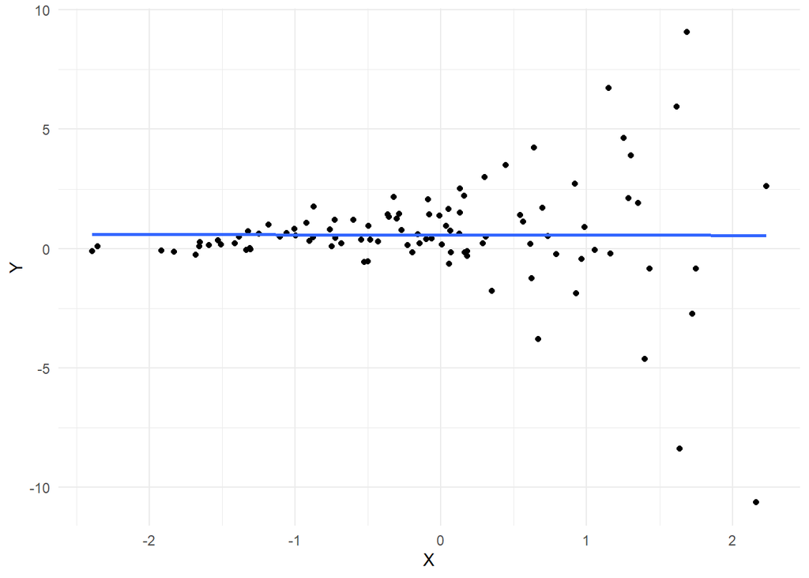

```r
ggplot(data, aes(x=X, y=Y)) +
  geom_point() +
  geom_smooth(method='lm', se=FALSE ) +
  theme_minimal()
```

Compare the heteroskedastic data:

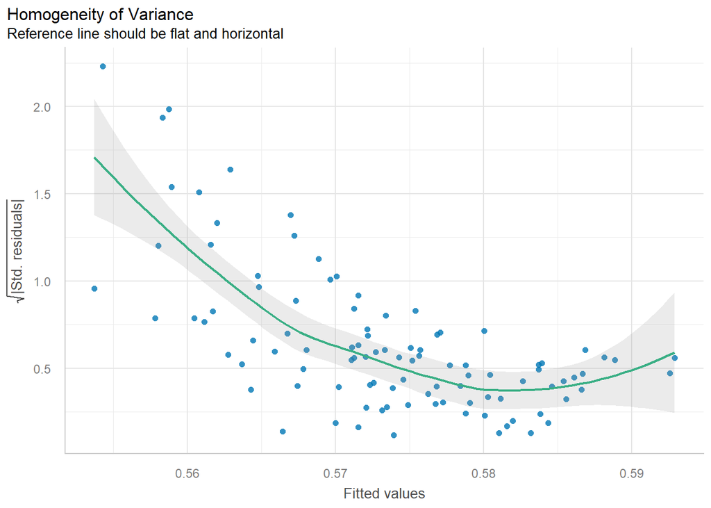

```r
checked<-check_heteroscedasticity(model)

plot(checked)
```

Vs. data without heteroskedasticity:

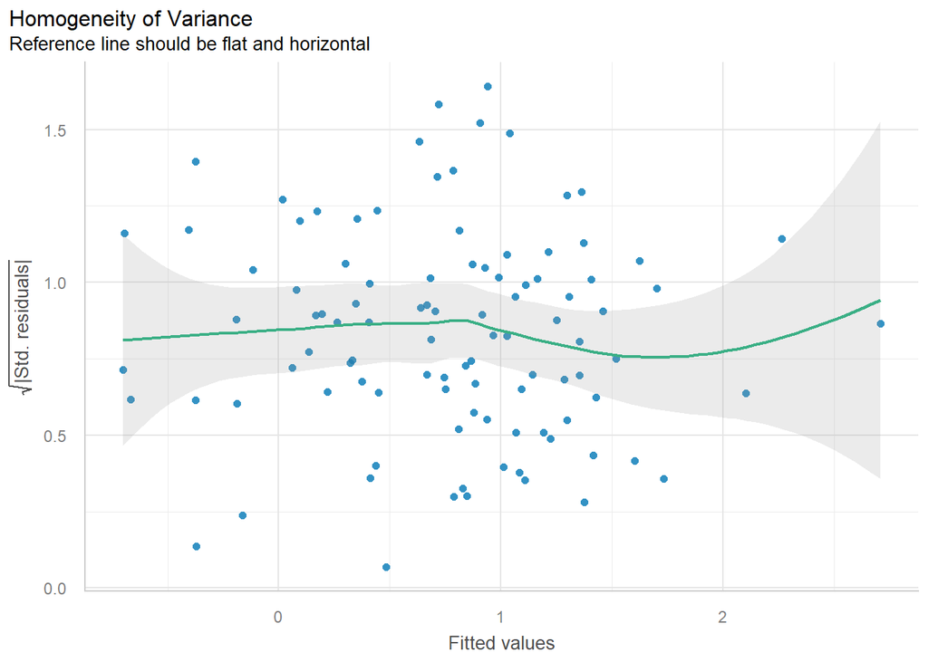

```r
hm_data<-tibble(X = cbind(rnorm(N, 0, 1)),
       e = rnorm(N, 0 , 1),
       Y = intercept  + X %*% betas + e)

model2<-lm(Y ~ X, data=hm_data)
checked<-check_heteroscedasticity(model2)

plot(checked)
```

## Simulation: What does heteroskedasticity do to our results?

To run a simulation, we can nest our data generating loop inside a function. We’ll also include an argument that allows us to vary the sample size:

```r
genFunc <- function(N=1000, homoskedastic=FALSE){
  betas <- 0
  X = cbind(runif(N, 1, 10))
  intercept = 1
  var =ifelse(homoskedastic, 1, exp(X))
  e = rnorm(N, 0 , var)
  Y <- intercept  + X %*% betas + e
  mod <- lm(Y ~ X)
  coefs<-tidy(mod, conf.int = TRUE, conf.level = .95)
  return(coefs)

}
```

Now, we can set up a list of parameters to pass along and then run our simulation.

```r
plist<-list(
  'N=20 homoskedastic' = list(N=25, homoskedastic=TRUE),
  'N=20 heteroskedastic' =  list(N=25),
  'N=100 homoskedastic' = list(N=100, homoskedastic=TRUE),
  'N=100 heteroskedastic' =  list(N=100)
)

results<- runSim(func=genFunc,
                 parmlist = plist,
                 seed = 999,
                 iterations=2000
)
```

Now plot the results…

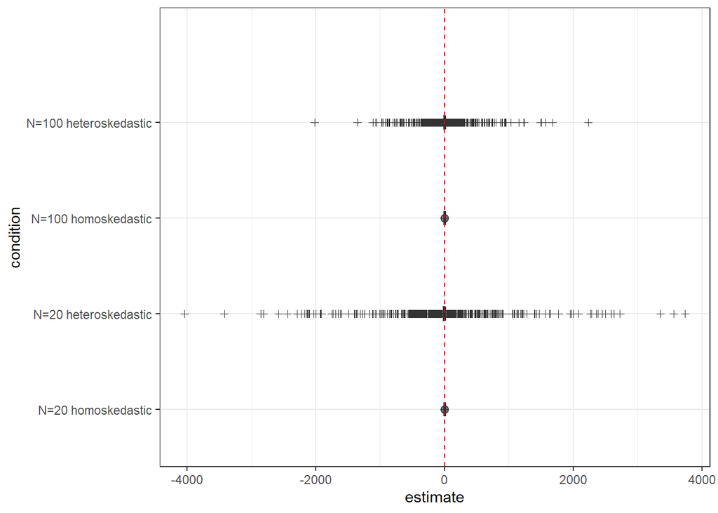

```r
results|>
    filter(term =="X")|>
  ggplot(aes(x =estimate, y = condition)) +
  stat_halfeye(
    alpha = .5,
    width = .6,
    .width = 0,
    justification = -.2
  ) +
  geom_boxplot(width = .15, outlier.shape = 3) +
  theme_bw() +
  geom_vline(xintercept=0.5, lty=2,col='red')
```

```r
results|>
  filter(term=="X")|>
  group_by(condition)|>
  summarize(simulated_sd = sd(estimate),
            estimated_se = median(std.error)
         )
```

| condition | simulated_sd | estimated_se |
| --- | --- | --- |
| N=20 homoskedastic | 0.07774921 | 0.07738298 |
| N=20 heteroskedastic | 439.96618516 | 17.36657022 |
| N=100 homoskedastic | 0.03711772 | 0.03859083 |
| N=100 heteroskedastic | 200.74656104 | 10.63388467 |

So what is happening here and how concerned should we be?